# Kickstart

Huayang Peng

## Introduction

Have you ever wondered if investing in that Kickstarter project was really worth your money or if it could actually reasonably succeed? With data on more than 300,000 Kickstarter projects from Kaggle and data science techniques that you will learn over the course of this article, you learn to be able to answer these questions yourself, and many more questions you have that can be answered through the principles of data science. To begin, you will learn how to curate and tidy data to ease your analysis. Following that, you will learn to perform exploratory data analysis using data transformations and visualizations, which will help you form hypotheses about the data. Last but certainly not least, you will learn to be able to test your newly-formed hypotheses through applied machine learning, and evaluate your machine learning model.

## Required Tools

We will be conducting our analysis in R using **RStudio**, an IDE for R that you can obtain [here](http://rstudio.com).

We will also be using the following libraries in R:

- tidyverse, a collection of fantastic data manipulation tools
- randomForest, a library that implements tree-based learning
- caret, a library that facilitates model optimization through cross-validation
- ROCR, a library that enables model evaluation

All of these libraries can be installed using the command `install.packages()` in the RStudio console. View documentation for any of the R functions mentioned in this article by appending `?` to the function, and omitting any parentheses and arguments.

# 1. Getting Ready

- http://www.r-tutor.com/r-introduction/data-frame
- https://www.tidyverse.org

```r
set.seed(4321)
kickstarter <- read.csv("ks-projects-201801.csv")
kickstarter <- as_data_frame(kickstarter)
kickstarter <- kickstarter %>%
  sample_n(10000)
kickstarter
```

```
## # A tibble: 10,000 x 15
##         ID name    category main_category currency deadline  goal launched
##      <int> <fct>   <fct>    <fct>         <fct>    <fct>    <dbl> <fct>
##  1  1.64e⁹ SKULL … Apparel  Fashion       AUD      2015-10…  1500 2015-09…
##  2  8.23e⁸ ECO La… Product… Design        GBP      2013-12…   500 2013-11…
##  3  1.79e⁹ Human … Comics   Comics        USD      2012-08… 10000 2012-07…
##  4  1.08e⁹ Queen … Documen… Film & Video  USD      2012-06…  1000 2012-05…
##  5  5.41e⁸ CHOX -… Food     Food          EUR      2016-12… 20000 2016-11…
##  6  5.16e⁸ "HUI -… Gadgets  Technology    EUR      2015-11…  2800 2015-09…
##  7  6.13e⁸ Binoke… Accesso… Fashion       EUR      2017-08… 30000 2017-07…
##  8  7.77e⁸ "\"The… Painting Art           USD      2013-12…  5500 2013-11…
##  9  1.86e⁹ Native… Food     Food          USD      2013-05… 20000 2013-04…
## 10  1.94e⁹ Woven … Accesso… Fashion       AUD      2018-01…  2000 2017-11…
## # ... with 9,990 more rows, and 7 more variables: pledged <dbl>,
## #   state <fct>, backers <int>, country <fct>, usd.pledged <dbl>,
## #   usd_pledged_real <dbl>, usd_goal_real <dbl>
```

### 1.1 Reviewing Our Data

Now we have a dataframe containing 10,000 observations from our original 300,000 superset. We have a few columns that we will have no use for for our purposes.

### 1.2 Tidying the Data

When we read in our data, R automatically parsed the columns into certain types of data. For ID, for example, it was parsed as an integer column, which is correct. However, for some columns such as dates and times, R will parse them as **factor** columns, which means that they assume discrete values, which does not express the nuance of dates and times. So we must tell R to re-parse these columns as datetime columns, using `readr` commands. While we are doing so, we will also drop the ancillary columns such as name that will have no relevance to any analysis we are interested in performing.

```r
kickstarter <- kickstarter %>%
  mutate(launched=as.character(launched),
  deadline=as.character(deadline)) %>%
  dplyr::select(-name) %>%
  readr::type_convert(readr::cols(deadline=readr::col_datetime("%Y-%m-%d"), launched=readr::col_datetime("%Y-%m-%d %H:%M:%S")))

kickstarter
```

```
## # A tibble: 10,000 x 14
##           ID category     main_category currency deadline             goal
##        <int> <fct>        <fct>         <fct>    <dttm>              <dbl>
##  1    1.64e⁹ Apparel      Fashion       AUD      2015-10-17 00:00:00  1500
##  2    8.23e⁸ Product Des… Design        GBP      2013-12-19 00:00:00   500
##  3    1.79e⁹ Comics       Comics        USD      2012-08-27 00:00:00 10000
##  4    1.08e⁹ Documentary  Film & Video  USD      2012-06-02 00:00:00  1000
##  5    5.41e⁸ Food         Food          EUR      2016-12-18 00:00:00 20000
##  6    5.16e⁸ Gadgets      Technology    EUR      2015-11-23 00:00:00  2800
##  7    6.13e⁸ Accessories  Fashion       EUR      2017-08-24 00:00:00 30000
##  8    7.77e⁸ Painting     Art           USD      2013-12-21 00:00:00  5500
##  9    1.86e⁹ Food         Food          USD      2013-05-20 00:00:00 20000
## 10    1.94e⁹ Accessories  Fashion       AUD      2018-01-13 00:00:00  2000
## # ... with 9,990 more rows, and 8 more variables: launched <dttm>,
## #   pledged <dbl>, state <fct>, backers <int>, country <fct>,
## #   usd.pledged <dbl>, usd_pledged_real <dbl>, usd_goal_real <dbl>
```

Next, notice that there are some observations that exist in an undefined state, and result in missing usd.pledged values and invalid country values. We will remove these observations as they exhibit an ambiguous success/failure state and would not be useful for us in analyzing project success/failure. There are other ways of dealing with such missing data; further reading can be found at http://www.hcbravo.org/IntroDataSci/bookdown-notes/eda-handling-missing-data.html. We will also condense the success/failure states into only success and failure, interpreting negative states as failure, positive states as success, and removing live states because they provide no useful information as to success/failure. Finally, we will remove the project currency columns (pledged, goal) in favor of the usd_pledged and usd_goal columns, as they are standard across all projects. We will ignore usd_pledged as it is simply another conversion to USD, according to the dataset spec. We also do not need the ID column, as it is simply kickstarter metadata. We will use the dplyr functions `filter` and `mutate` to accomplish these goals.

```r
kickstarter <- kickstarter %>%
  filter(state != "live") %>%
  filter(state != "undefined") %>%
  mutate(state = ifelse(state=="successful", "success", "failure")) %>%
  select(-currency, -goal, -pledged, -usd.pledged, -ID) %>%
  rename(pledged = usd_pledged_real, goal = usd_goal_real)

kickstarter
```

```
## # A tibble: 9,829 x 9
##    category    main_category deadline            launched            state
##    <fct>       <fct>         <dttm>              <dttm>              <chr>
##  1 Apparel     Fashion       2015-10-17 00:00:00 2015-09-19 00:37:09 fail…
##  2 Product De… Design        2013-12-19 00:00:00 2013-11-28 02:37:40 fail…
##  3 Comics      Comics        2012-08-27 00:00:00 2012-07-28 00:21:54 fail…
##  4 Documentary Film & Video  2012-06-02 00:00:00 2012-05-03 22:14:14 fail…
##  5 Food        Food          2016-12-18 00:00:00 2016-11-18 10:02:41 fail…
##  6 Gadgets     Technology    2015-11-23 00:00:00 2015-09-29 12:59:43 succ…
##  7 Accessories Fashion       2017-08-24 00:00:00 2017-07-25 00:04:16 fail…
##  8 Painting    Art           2013-12-21 00:00:00 2013-11-21 01:42:36 fail…
##  9 Food        Food          2013-05-20 00:00:00 2013-04-19 04:49:34 fail…
## 10 Graphic De… Design        2015-05-16 00:00:00 2015-04-16 22:15:19 fail…
## # ... with 9,819 more rows, and 4 more variables: backers <int>,
## #   country <fct>, pledged <dbl>, goal <dbl>
```

## 2. Exploratory Data Analysis

Now that we have tidied our data, we can begin to analyze our data for interesting hypotheses and trends. The purpose of our analysis in this section is to uncover patterns in our data so that we may devise testable hypotheses. We will use data visualization and statistical measurements as our analytical tools of choice.

### 2.1 Time Series Analysis

As a first naïve foray, we will attempt to see if project success depends on the time that the project was launched. We will plot the number of successful projects launched on each day to the number of failed projects launched on each day, and to do so we will employ ggplot2, or the grammar of graphics. This is a highly versatile and dynamic graphing library that is part of tidyverse, and it is highly recommended to familiarize yourself with it for future data visualization projects. More info can be found at http://ggplot2.tidyverse.org. A very useful cheat sheet for ggplot2 features can be found at https://www.rstudio.com/wp-content/uploads/2015/03/ggplot2-cheatsheet.pdf.

To create the data for our plot, we will use the `group_by` function provided by dplyr to get the number of rows that have the same launched date and were successes. We will have to get rid of the hour/minute/second granularity in launched to achieve the results we want. Again, for more on R functions such as `group_by()`, simply enter `?group_by` into the R console.

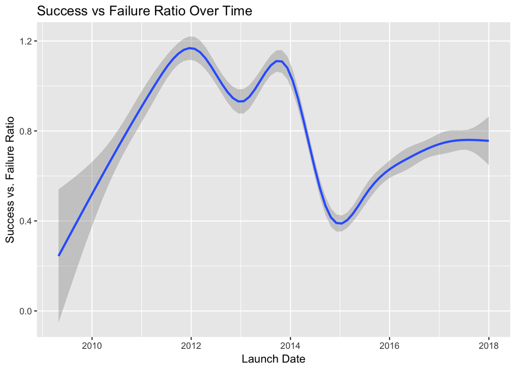

```r
kickstarter %>%
  #get just the date of the launched attribute
  mutate(launched = as.Date(launched)) %>%
  group_by(launched) %>%
  #sum up number of successes and failures for each single date
  mutate(successes = sum(ifelse(state=="success", 1, 0)), failures = sum(ifelse(state=="failure", 1, 0)), ratio = ifelse(failures==0, successes, successes/failures)) %>%
  select(launched, ratio) %>%
  ggplot(aes(x=launched, y=ratio)) +
  geom_smooth() +
  labs(x="Launch Date", y="Success vs. Failure Ratio", title="Success vs Failure Ratio Over Time")
```

### 2.1.2 Stastical Measures

From this graph, it would appear that there has been no particularly auspicious day in which projects launched on that day were much more likely to succeed than fail. The overall variance of the ratio appears to remain low once Kickstarter reached relative maturity as a crowdfunding platform. Therefore, there does not appear to be a strong correlation between launched date and the viability of projects released on that date.

We can obtain more information from this measure by looking at the mean success to failure ratio over all days and the standard deviation:

```r
temp_df <- kickstarter %>%
  #get just the date of the launched attribute
  mutate(launched = as.Date(launched)) %>%
  group_by(launched) %>%
  #sum up number of successes and failures for each single date
  mutate(successes = sum(ifelse(state=="success", 1, 0)), failures = sum(ifelse(state=="failure", 1, 0)), ratio = ifelse(failures==0, successes, successes/failures)) %>%
  select(launched, ratio)

#display the mean
mean(temp_df$ratio)
```

```
## [1] 0.7580385
```

```r
#display the standard deviation
sd(temp_df$ratio)
```

```
## [1] 0.8173245
```

### 2.2 Categories

Next, we can examine if there is a relationship between main category of Kickstarter projects and their tendencies to succeed. It’s possible that certain categories of products or services are more popular than others, and therefore have higher chances to succeed. We will also be grouping the subcategory with the main category in our analysis for added granularity, so we will be looking at category, main category pairs versus success to failure ratio. We will once again be using ggplot2 and group_by to construct our visualization.

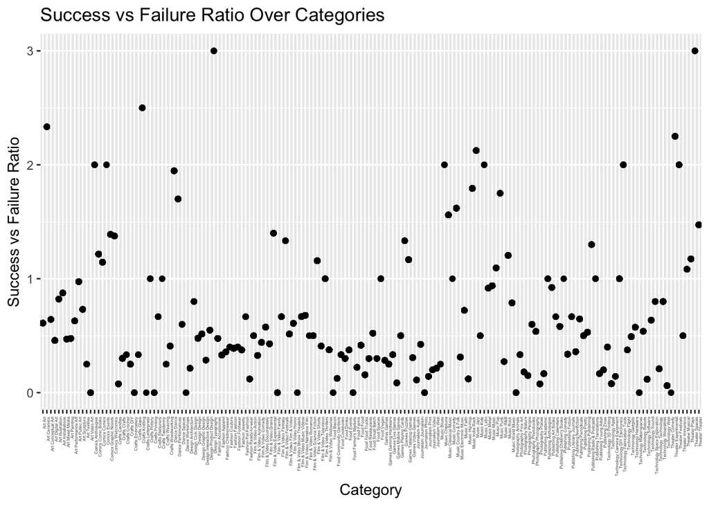

```r
kickstarter %>%
  group_by(category, main_category) %>%
  #sum up number of successes for a single date
  mutate(successes = sum(ifelse(state=="success", 1, 0)), failures = sum(ifelse(state=="failure", 1, 0)), ratio = ifelse(failures==0, successes, successes/failures)) %>%
  arrange(desc(ratio)) %>%
  mutate(category_overall = paste(main_category, category)) %>%
  ggplot(aes(x=category_overall, y=ratio)) +
  #rotates x-axis labels so that they are vertically aligned
  theme(axis.text.x = element_text(angle = 90, hjust = 1, size=3)) +
  labs(x="Category", y="Success vs Failure Ratio", title="Success vs Failure Ratio Over Categories") +
  geom_point()
```

### 2.2.1 Statistical Measures

It’s clear from the plot above that there are strong relationships between successful projects and their categories, as categories such as Design, Crafts, and Theater have very high success to failure ratios.

We can take the mean and standard deviation across all categories to see what the success to failure ratio is like for the average category, as well as get a gauge on how the spread of the ratio looks across categories.

```r
temp_df <- kickstarter %>%
  group_by(category, main_category) %>%
  #sum up number of successes for a single date
  mutate(successes = sum(ifelse(state=="success", 1, 0)), failures = sum(ifelse(state=="failure", 1, 0)), ratio = ifelse(failures==0, successes, successes/failures)) %>%
  arrange(desc(ratio)) %>%
  mutate(category_overall = paste(main_category, category))

#display mean ratio over categories
mean(temp_df$ratio)
```

```
## [1] 0.6602645
```

```r
#display standard deviation of ratio over categories
sd(temp_df$ratio)
```

```
## [1] 0.443755
```

## 2.3 Campaign Time

Looking at the data once more, it seems that there may be a correlation between how long a campaign lasts and its chance of succeeding. We will need to create a new attribute representing the length of the campaign in days, and use `group_by` on that in order to visualize the trend, if any, of success to failure ratio versus campaign length.

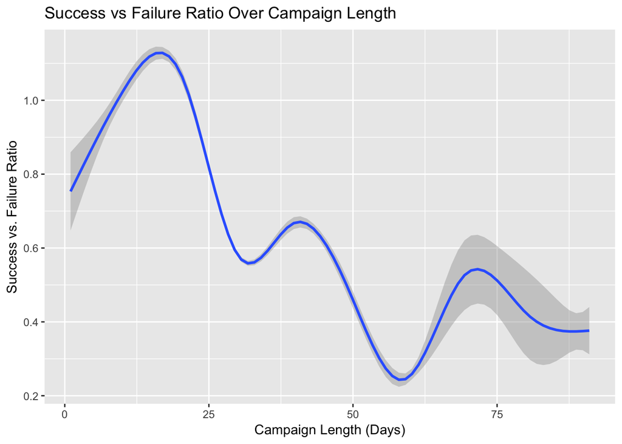

```r
kickstarter %>%
  #get just the date of the launched attribute
  mutate(len = as.numeric(as.Date(deadline) - as.Date(launched), units="days")) %>%
  group_by(len) %>%
  #sum up number of successes and failures for each single date
  mutate(successes = sum(ifelse(state=="success", 1, 0)), failures = sum(ifelse(state=="failure", 1, 0)), ratio = ifelse(failures==0, successes, successes/failures)) %>%
  select(len, ratio) %>%
  ggplot(aes(x=len, y=ratio)) +
  geom_smooth() +
  labs(x="Campaign Length (Days)", y="Success vs. Failure Ratio", title="Success vs Failure Ratio Over Campaign Length")
```

### 2.3.1 Statistical Measurements

From the above graph, it appears that there is a distinct downward trend between success vs failure ratio and campaign length, with the ratio trending downward as campaign length increases, up to a certain point at which the variance of the data grows. A natural question to follow up on at this point is what does the ratio look like for the average campaign length? Taking the mean of the ratio over all campaign lengths and finding its standard deviation would grant us additional insight.

```r
temp_df <- kickstarter %>%
  #get just the date of the launched attribute
  mutate(len = as.numeric(as.Date(deadline) - as.Date(launched), units="days")) %>%
  group_by(len) %>%
  #sum up number of successes & failures for each single date
  mutate(successes = sum(ifelse(state=="success", 1, 0)), failures = sum(ifelse(state=="failure", 1, 0)), ratio = ifelse(failures==0, successes, successes/failures)) %>%
  select(len, ratio)

#display mean of ratios over campaign lengths
ratio_mean <- mean(temp_df$ratio)
ratio_mean
```

```
## [1] 0.6118364
```

```r
#display standard deviation of ratios over campaign lengths
ratio_sd <- sd(temp_df$ratio)
ratio_sd
```

```
## [1] 0.309901
```

To obtain an even clearer view of trends in the data, we can apply a standardizing transformation to ratio that will both center and scale its values. The standardizing transformation is typically $\frac{(x_i-\bar{x})}{sd(x)}$, and is commonly applied to ease interpretation of data analysis. For more information on common data transformations in data science, visit http://www.hcbravo.org/IntroDataSci/bookdown-notes/eda-data-transformations.html.

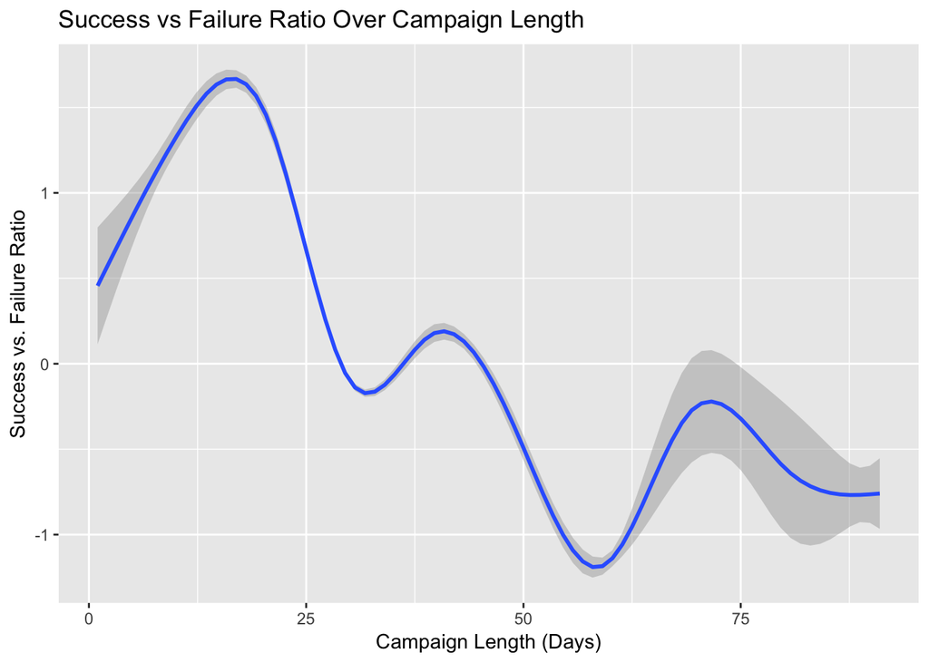

```r
kickstarter %>%
  #get just the date of the launched attribute
  mutate(len = as.numeric(as.Date(deadline) - as.Date(launched), units="days")) %>%
  group_by(len) %>%
  #sum up number of successes and failures for each single date
  mutate(successes = sum(ifelse(state=="success", 1, 0)), failures = sum(ifelse(state=="failure", 1, 0)), ratio = ifelse(failures==0, successes, successes/failures)) %>%
  mutate(ratio_sd = (ratio-ratio_mean)/ratio_sd) %>%
  select(len, ratio_sd) %>%
  ggplot(aes(x=len, y=ratio_sd)) +
  geom_smooth() +
  labs(x="Campaign Length (Days)", y="Success vs. Failure Ratio", title="Success vs Failure Ratio Over Campaign Length")
```

We can see that the same trend still holds under the standardizing transformation.

## 3. Machine Learning

Machine learning greatly helps with uncovering patterns in data and making predictions based off of such patterns. We will use a particular type of machine learning in this tutorial called supervised machine learning, which means that we will train a predictive model based on a training dataset, and we will test the model by having it predict labels for a separate, test dataset. For further reading on the different types of machine learning methods, begin with https://medium.com/deep-math-machine-learning-ai/different-types-of-machine-learning-and-their-types-34760b9128a2.

### 3.1 Choosing a Hypothesis

To begin, we must decide what we would like to predict. Based on our Exploratory Data Analysis, it appears that we could predict whether or not a campaign succeeds or fails based on its planned campaign length. So the goal of our model will be to take as input a length of time in days, and output a class of success or failure.

The relationship between planned campaign length and success or failure does not appear to be linear, so we will use a non-linear predictive model called a random forest to model it. The random forest outputs multitudes of decision trees, which are essentially yes/no questions that take our length as their inputs, ask questions about it, and output predictions based on the answers to its questions. The random forest then takes the mode of their predictions, and that becomes the overall prediction. To read more on random forests, here is an article on random forests and another on random forests in R:

- [Random Forests](https://towardsdatascience.com/the-random-forest-algorithm-d457d499ffcd)
- [Random Forests in R](http://trevorstephens.com/kaggle-titanic-tutorial/r-part-5-random-forests/)

### 3.2 Random Forests

The way random forests work is that they use $n$ decision trees ([more on decision trees](https://towardsdatascience.com/decision-trees-in-machine-learning-641b9c4e8052)) to calculate a mode prediction that is then output. This $n$ must be manually chosen, and it may not be obvious at first what an optimal value of n is, but we will soon see how to select for optimal values of $n$. To begin, we should do a sample run of a random forest just to see how it works.

Since we want to predict whether or not a campaign succeeds, it follows that our y-value or output should be the state of the campaign, either failure or success. And because we are predicting this based off of campaign lengths, it is also clear that our x-value or input should be the number of days between a campaign’s launch date and a campaign’s deadline.

```r
#create campaign length attribute and select 20% of dataset for demonstration
parent_set <- kickstarter %>%
  mutate(len = as.numeric(as.Date(deadline) - as.Date(launched), units="days")) %>%
  select(state, len) %>%
  sample_frac(.2) %>%
  rowid_to_column()

#convert state into a factor
parent_set$state <- factor(parent_set$state)

#sample 20% of parent dataset out as test dataset
test_set <- parent_set %>%
  sample_frac(.2)

#leave rest of parent dataset for training and remove rowid attribute
train_set <- parent_set %>%
  anti_join(test_set, by="rowid") %>%
  select(-rowid)

test_set <- test_set %>%
  select(-rowid)

#ntree indicates the number of decision trees, predicting state from other attributes
rf <- randomForest(state~., data=train_set, ntree=1000)
rf
```

```
##
## Call:
##  randomForest(formula = state ~ ., data = train_set, ntree = 1000)
##                Type of random forest: classification
##                      Number of trees: 1000
## No. of variables tried at each split: 1
##
##         OOB estimate of  error rate: 33.69%
## Confusion matrix:
##         failure success class.error
## failure     928     106   0.1025145
## success     424     115   0.7866419
```

### 3.3 Preparing The Data

We are at the point where we need to split our data into test and training categories. We cannot reverse the split once we perform it, as given the hypothetical scenario where we use some test data to train our predictor, we could make our predictor seem to perform better than it really is.

Generally, we aim to have more data set aside for training than testing, so in this case we will set aside 30% of our data for testing purposes, and the rest for training.

```r
#create campaign length attribute and select 20% of dataset for demonstration
temp_df <- kickstarter %>%
  mutate(len = as.numeric(as.Date(deadline) - as.Date(launched), units="days")) %>%
  select(state, len) %>%
  rowid_to_column()

#convert state into a factor
temp_df$state <- factor(temp_df$state)

test_set <- temp_df %>% sample_frac(.3)
train_set <- temp_df %>% anti_join(test_set, by="rowid")
```

### 3.4 Selecting Hyperparameters

#### 3.4.1 Overfitting

It may seem intuitive that the higher the value of ntree is the better, since more trees means a greater tendency to get the correct answer as the mode of the predictions. However, this is a logical fallacy, as when ntree is too great, we will begin to overly conform to our training dataset, leading to poorer generalizability to the test dataset and real-world applications. We would like to avoid this as much as possible, as it destroys the utility of the predictor. Overfitting is a complex issue, and you can learn more at https://www.geeksforgeeks.org/underfitting-and-overfitting-in-machine-learning/, which also explains the more intuitive concept of underfitting.

#### 3.4.2 Cross-Validation

We would like to avoid overfitting, but we also cannot utilize our test dataset during training to help because then there would be no data to do valid tests on. Here is where cross validation comes in. Instead of using our test dataset, we split our training dataset into a training set and a validation set, performing as many splits as hyperparameter values we want to test. By comparing the performances of each predictor on each split, we can determine the best hyperparameter value out of those we have chosen to test, and then we will be able to use that value to run our predictor on the test dataset.

Due to processing power limitations, we will only be testing two values of ntree, but we will be performing 10-fold (10-way split) cross validation to determine the better performing value.

```r
train_set <- train_set %>% select(-rowid)
test_set <- test_set %>% select(-rowid)

result_df <- createFolds(train_set$state, k=10) %>%
  # fit models and gather results
  purrr::imap(function(test_indices, fold_number) {
    # split into train and test for the fold
    train_df <- train_set %>%
      slice(-test_indices)

    test_df <- train_set %>%
      slice(test_indices)

    # fit the two models
    rf1 <- randomForest(state~., data=train_df, ntree=200)
    rf2 <- randomForest(state~., data=train_df, ntree=800)

    # gather results
    test_df %>%
      select(observed_label = state) %>%
      mutate(fold=fold_number) %>%
      mutate(prob_positive_rf1 = predict(rf1, newdata=test_df, type="prob")[,"success"]) %>%
      # add predicted labels for rf1 using a 0.5 probability cutoff
      mutate(predicted_label_rf1 = ifelse(prob_positive_rf1 > 0.5, "success", "failure")) %>%
      mutate(prob_positive_rf2 = predict(rf2, newdata=test_df, type="prob")[,"success"]) %>%
      # add predicted labels for rf2 using a 0.5 probability cutoff
      mutate(predicted_label_rf2 = ifelse(prob_positive_rf2 > 0.5, "success", "failure"))
}) %>%
  # combine the ten result data frames into one
  purrr::reduce(bind_rows)
result_df
```

```
## # A tibble: 6,880 x 6
##    observed_label fold  prob_positive_r… predicted_label… prob_positive_r…
##    <fct>          <chr>            <dbl> <chr>                       <dbl>
##  1 failure        Fold…           0      failure                    0
##  2 success        Fold…           0      failure                    0
##  3 failure        Fold…           0      failure                    0
##  4 failure        Fold…           0.115  failure                    0.109
##  5 success        Fold…           0      failure                    0
##  6 failure        Fold…           0      failure                    0
##  7 success        Fold…           0      failure                    0
##  8 failure        Fold…           0      failure                    0
##  9 failure        Fold…           0      failure                    0
## 10 failure        Fold…           0.0350 failure                    0.0550
## # ... with 6,870 more rows, and 1 more variable: predicted_label_rf2 <chr>
```

The above dataframe describes what each value of ntree predicted for each entry in each validation test. We can reduce this table into a more interpretable form using the ROCR library introduced at the very beginning of this tutorial, and determine a winner.

#### 3.4.3 ROC & AUROC

To better interpret which ntree value is better, we will draw a Receiver Operating Characteristic curve (ROC curve for short), and find the Area Under the ROC (AUROC) for both ntree values. The ROC curve plots on its y-axis the true positive rate of the ntree value, which is how often that the positive outcome is correctly predicted, and on its x-axis it plots the false positive rate, which is how often that the classifier incorrectly predicts a positive outcome, when the true class is the negative outcome. Under these circumstances, the greater the AUROC, generally the better performing the value is. For more on AUROC and classifier evaluation, see http://www.hcbravo.org/IntroDataSci/bookdown-notes/linear-models-for-classification.html#classifier-evaluation.

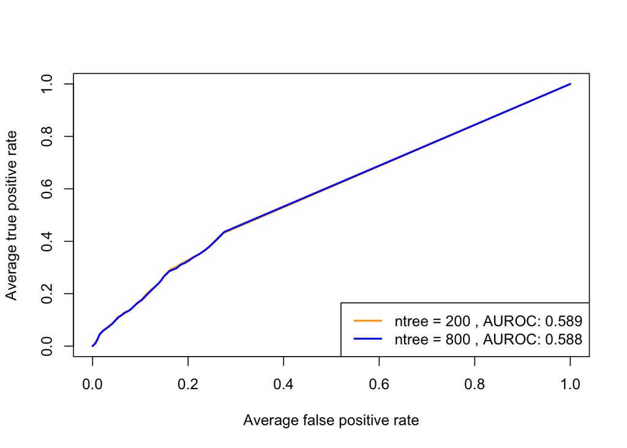

```r
labels <- split(result_df$observed_label, result_df$fold)

#ntree=200 predictions
predictions_rf1 <- split(result_df$prob_positive_rf1, result_df$fold) %>% prediction(labels)

#ntree=800 predictions
predictions_rf2 <- split(result_df$prob_positive_rf2, result_df$fold) %>% prediction(labels)

mean_auc_rf1 <- predictions_rf1 %>%
  performance(measure="auc") %>%

  slot("y.values") %>% unlist() %>%
  mean()

mean_auc_rf2 <- predictions_rf2 %>%
  performance(measure="auc") %>%
  slot("y.values") %>% unlist() %>%
  mean()

predictions_rf1 %>%
  performance(measure="tpr", x.measure="fpr") %>%
  plot(avg="threshold", col="orange", lwd=2)

predictions_rf2 %>%
  performance(measure="tpr", x.measure="fpr") %>%
  plot(avg="threshold", col="blue", lwd=2, add=TRUE)

legend("bottomright",
       legend=paste(c("ntree = 200", "ntree = 800"), ", AUROC:", round(c(mean_auc_rf1, mean_auc_rf2), digits=3)),
       col=c("orange", "blue"), lwd=2)
```

From the ROC curve and AUROC values above, it appears that the ntree value does not particularly matter, at least between the two that were tested. The ROC curves overlap for most of their lengths, and the AUROC values are nearly indistinguishable. Therefore let’s choose $ntree = 800$ for our hyperparameter and run our classifier on the test dataset.

#### 3.4.4 Test Dataset Evaluation

```r
rf <- randomForest(state~., data=train_set, ntree=800)
results <- test_set %>%
      select(observed_label = state) %>%
      mutate(prob_positive_rf = predict(rf, newdata=test_set, type="prob")[,"success"]) %>%
      # add predicted labels for rf using 0.5 probability cutoff
      mutate(predicted_label_rf = ifelse(prob_positive_rf > 0.5, "success", "failure"))

results
```

```
## # A tibble: 2,949 x 3
##    observed_label prob_positive_rf predicted_label_rf
##    <fct>                     <dbl> <chr>
##  1 failure                  0      failure
##  2 failure                  0      failure
##  3 failure                  0.0175 failure
##  4 failure                  0      failure
##  5 failure                  0      failure
##  6 failure                  0      failure
##  7 failure                  0.522  success
##  8 failure                  0      failure
##  9 failure                  0      failure
## 10 success                  0      failure
## # ... with 2,939 more rows
```

Given that the dataframe’s values are difficult to interpret, we can draw a ROC curve and obtain the AUROC to get a better, more quantitative view of our model’s performance.

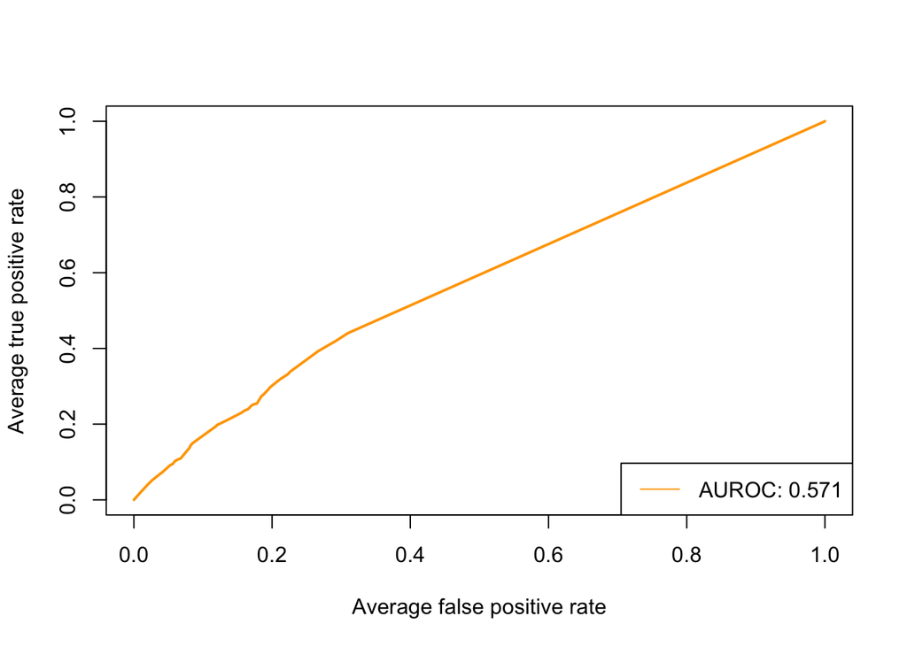

```r
#get true labels
labels <- results$observed_label
#get list of predictions from test results and pass to ROCR prediction function
predictions_rf <- results$prob_positive_rf %>% prediction(labels)

#calculate average AUROC for the random forest
mean_auc_rf <- predictions_rf %>%
  performance(measure="auc") %>%
  slot("y.values") %>% unlist() %>%
  mean()

#plot ROC curve
predictions_rf %>%
  performance(measure="tpr", x.measure="fpr") %>%
  plot(avg="threshold", col="orange", lwd=2)

legend("bottomright",
       legend=paste("AUROC:", round(mean_auc_rf, digits=3)),
       col="orange", lwd=1)
```

The AUROC and the ROC curve indicate that our model is not performing amazingly, but decidedly average, as the ROC curve is nearly a diagonal line. The best ROC curve would be one that has a sharp increase in true positive rate at the low false positive rates, and levels off at a high true positive rate early on. A very poor ROC curve would be one that looked like an exponential graph, so that the true positive rate remains low and only attains a high true positive rate when the false positive rate is high.

Still, although our model did not perform spectacularly, based on our exploratory analysis, there does appear to be a relationship between a campaign making or breaking it and its length.

## Conclusion

Knowing if a Kickstarter campaign will make it through to success could save a lot of money, time, and stress. This is what data scientists should strive for—to embetter and empower people.

Knowing that there is some relationship between campaign lengths and campaign chances of success allows Kickstarter frequenters to better hedge their bets and prepare for possible disappointment—it also helps potential Kickstarters to plan out their campaigns for a maximal chance of successfully funding their campaign.

We recommend the reader download and experiment with this dataset at his or her own leisure.

## References

- CMSC320, Dr. Bravo - http://www.hcbravo.org/IntroDataSci/bookdown-notes/
- Tidyverse - https://www.tidyverse.org/
  - Ggplot2 - http://ggplot2.tidyverse.org/
- ROCR - https://rocr.bioinf.mpi-sb.mpg.de/
- RandomForest - https://cran.r-project.org/web/packages/randomForest/randomForest.pdf
- Readr - https://cran.r-project.org/web/packages/readr/readr.pdf
- Caret - http://caret.r-forge.r-project.org/
- Kaggle Datasets - https://www.kaggle.com/datasets
  - Kickstarter Dataset - https://www.kaggle.com/kemical/kickstarter-projects
- RStudio - https://www.rstudio.com/